# CSI 4142 Fundamentals of Data Science, Winter 2025

# Project 4 - Unsupervised Learning (Clustring and Recommendations)

# Part 1 : Study 2 & 4 - Clustering Algorithms and Collaborative Filtering Recommendation System

### Hilaire Junior Kalala - 300289737

## 1. Introduction

Unsupervised learning techniques are widely used across various domains such as business, finance, healthcare, environmental science, and more to extract valuable insights from data. This project aims to apply key unsupervised learning methods and tools to address real-world problems effectively.

The project is divided into two parts, each containing two studies, using a recommendation dataset as the basis for analysis.

- **Part 1** explores clustering algorithms and collaborative filtering recommendation systems:
  - The first study focuses on clustering, where K-Means and DBSCAN algorithms will be tested. Their performance will be evaluated using visual inspection techniques to determine the most suitable method for the given dataset.
  - The second study involves building a collaborative filtering-based recommendation system, which will be assessed through both qualitative and quantitative evaluations to measure its effectiveness.
- **Part 2** delves into similarity measures and content-based recommendation systems:
  - The third study investigates various similarity measures, examining their impact on classifying the dataset and their role in improving recommendation performance.
  - The final study involves developing a content-based recommendation system, leveraging domain-specific heuristics to enhance recommendations.

Each step of this project is fully reproducible and well-documented to facilitate understanding. To avoid execution errors, it is recommended to run the notebook cells sequentially from top to bottom.

## 2. Preparation of the data

In this section, I will introduce the Anime Recommendation Dataset selected for the upcoming studies. I will first explore the dataset, conduct validity checks on its features, and identify any inconsistencies. Then, I will perform outlier detection and removal before applying feature engineering techniques to refine the dataset and prepare it for analysis.

### A. Dataset presentation : Anime Recommendations Database

This dataset contains information on user preference data from 73,516 users on 12,294 anime. Each user is able to add anime to their completed list and give it a rating and this data set is a compilation of those ratings.

- Anime.csv
  - anime_id - myanimelist.net's unique id identifying an anime.
  - name - full name of anime.
  - genre - comma separated list of genres for this anime.
  - type - movie, TV, OVA, etc.
  - episodes - how many episodes in this show. (1 if movie).
  - rating - average rating out of 10 for this anime.
  - members - number of community members that are in this anime's "group".
- Rating.csv
  - user_id - non identifiable randomly generated user id.
  - anime_id - the anime that this user has rated.
  - rating - rating out of 10 this user has assigned (-1 if the user watched it but didn't assign a rating).

```python
# Initialization of libraries and dataset.
import os
import numpy as np
import pandas as pd

anime = pd.read_csv("https://raw.githubusercontent.com/hkala042/Hil_datasets/refs/heads/main/anime.csv")
anime.info()
anime.describe()
```

```
<class 'pandas.core.frame.DataFrame'>
RangeIndex: 12294 entries, 0 to 12293
Data columns (total 7 columns):
 #   Column    Non-Null Count  Dtype
---  ------    --------------  -----
 0   anime_id  12294 non-null  int64
 1   name      12294 non-null  object
 2   genre     12232 non-null  object
 3   type      12269 non-null  object
 4   episodes  12294 non-null  object
 5   rating    12064 non-null  float64
 6   members   12294 non-null  int64
dtypes: float64(1), int64(2), object(4)
memory usage: 672.5+ KB
```

|  | anime_id | rating | members |
| --- | --- | --- | --- |
| count | 12294.000000 | 12064.000000 | 1.229400e+04 |
| mean | 14058.221653 | 6.473902 | 1.807134e+04 |
| std | 11455.294701 | 1.026746 | 5.482068e+04 |
| min | 1.000000 | 1.670000 | 5.000000e+00 |
| 25% | 3484.250000 | 5.880000 | 2.250000e+02 |
| 50% | 10260.500000 | 6.570000 | 1.550000e+03 |
| 75% | 24794.500000 | 7.180000 | 9.437000e+03 |
| max | 34527.000000 | 10.000000 | 1.013917e+06 |

### B. Data cleaning

#### 1. Missing values imputations

```python
# The first step is to handle missing values of the dataset
# I am going to use the Machine Learning based functions from LightGBM to impute the missing values of the dataset
from sklearn.model_selection import GridSearchCV
from sklearn.ensemble import RandomForestRegressor, RandomForestClassifier

# This function factorizes the dataframe by turning cateorical features into numerical features
def factorize(df):
    df_copy = df.copy()
    for cat_col in df_copy.select_dtypes(include=object):
        df_copy[cat_col] = pd.factorize(df_copy[cat_col])[0]
    return df_copy

# This function creates splits of the dataset, one for training and the other one for testing. To use in ùissing values imputation functions
def create_splits(df, col):
    train = df[df['is_nan'] == 0]
    test = df[df['is_nan'] == 1]

    X_train = train.drop([col, 'is_nan'], axis=1)
    y_train = train[col]
    X_test = test.drop([col, 'is_nan'], axis = 1)
    return X_train, y_train, X_test

# The function responsible for training the model and return the imputed missing values as predictions
# I am using the default settings here to build the predictive models that I am going to use to impute the missing values
def train_predict(mode, X_train, y_train, X_test):
    # Select model based on mode
    if mode == 'regression':
        model = RandomForestRegressor(n_estimators=100, max_depth=10, random_state=42)  # Default settings
    else:
        model = RandomForestClassifier(n_estimators=100, max_depth=10, random_state=42)

    # Train the model
    model.fit(X_train, y_train)

    # Predict missing values
    y_pred = model.predict(X_test)

    return y_pred

# The function that I am going to use to impute the missing values of numerical features
def impute_missing_values(df, cols_lst, mode):


    for col in cols_lst:
        # Drop the column if there are more than 50% of missing values
        if df[col].isnull().sum() > int(len(df)/2):
            df.drop(col, axis=1, inplace=True)
            print(f'Dropped {col} because it has more than 50% of the data missing')
        else:
            data = df.copy() # I am going to change the subset of the dataset for training and I don't want to change the original dataset
            # creating a new column 'is_nan' set to 1 for each row having a missing value on the 'col" attribute
            nan_indexes = data[data[col].isna()].index
            data['is_nan'] = 0
            data.loc[nan_indexes, 'is_nan'] = 1

            # Factorizing categorical features
            data_f = factorize(data.drop([col], axis=1))
            data_f[col] = data[col]

            # splitting the subset into into a train and testing set to train the model for missing values imputation
            X_train, y_train, X_test = create_splits(data_f, col)

            #Training the model using LGBMRegressor and impute missing values
            y_pred = train_predict(mode, X_train, y_train, X_test)

            #Now let's include the imputed values into the original dataset at the correct
            if pd.api.types.is_integer_dtype(df[col]):  # If the column is originally integer
                df.loc[nan_indexes, col] = y_pred.astype(int)  # Convert predictions to int
            elif pd.api.types.is_float_dtype(df[col]):  # If the column is originally float
                df.loc[nan_indexes, col] = y_pred.astype(float)  # Ensure predictions remain float
            else:
                df.loc[nan_indexes, col] = y_pred  # Default case

    return df
```

```python
# In this section, I am going to apply the impute_missing_values_function on the different features having missing values

# To handle missing values in the "episodes" column, I am going to replace the "Unknown" values by NaN values,
# transform the column into a numerical feature, then run the impute_missing_values function
unk_values = anime[anime.episodes == "Unknown"].index
anime.loc[unk_values, "episodes"] = "NaN"
anime["episodes"] = pd.to_numeric(anime["episodes"], errors="coerce").astype("Int64")

# Finding which columns have missing data
cols_with_nan = [ d for d in anime if anime[d].isnull().sum() > 0 ]
# Breaking down those columns into numeric and categoric data and store them in separate lists
num_cols = [col for col in anime[cols_with_nan].select_dtypes(exclude=object)]
cat_cols = [col for col in anime[cols_with_nan].select_dtypes(include=object)]

anime = impute_missing_values(anime, num_cols, 'regression')
anime = impute_missing_values(anime, cat_cols, 'classification')

anime.info()
```

[output not shown]

#### 2. Outlier detection and removal

```python
# The second step involves removing outliers
# I am going to use the Z-score method to detect the outliers in the different numerical features of the two datasets
from scipy import stats

def remove_outliers(df, attr):
    z_scores = np.abs(stats.zscore(df[attr]))
    df = df[z_scores <= 3]
    return df

anime = remove_outliers(anime, "rating")
anime = remove_outliers(anime, "members")
anime = remove_outliers(anime, "episodes")
```

#### 3. Validity checks and Feature engineering

```python
# I am first going to display the functions of the different validity checks to perform (Uniqueness, Look-up errors check and Exact duplicates check)

# The function that checks for unique values
def check_unique(df, attr):
    duplicates = df[df.duplicated(subset=[attr], keep='last')]
    return duplicates.index

# The function find_exactDuplicates will do exactly what his name stands for lol.
def find_exactDuplicates(df):
    df = df.drop_duplicates(keep = False)
    return df

# The function Look_up that takes the attribute and a table of acceptable values in parameters
def look_up( df, attr, acc_values):
    invalid_indexes = df.index[~df[attr].isin(acc_values)]
    return invalid_indexes
```

```python
# In this cell, I am going to check for some validity requirements on different features (Uniqueness for "anime_id", uniqueness of rows,
# and the "type" values belong to a predefined list of acceptable values)

# Check the uniqueness in the "anime_id" feature
print(check_unique(anime, "anime_id"))

# Remove the exact duplicates if found
find_exactDuplicates(anime)

# Verify that the values in the "type" belong to a predefined list of acceptable values
poss_values = ['TV', 'Movie', 'Special', 'OVA', 'ONA', 'Music']
invalid_rows = anime.loc[look_up(anime, "type", poss_values), "type"]
invalid_rows.head()

# anime.to_csv("Anime_clean.csv")

anime = pd.read_csv("https://raw.githubusercontent.com/hkala042/Hil_datasets/refs/heads/main/Anime_clean.csv")
```

```
Index([], dtype='int64')
```

```python
# Feature engineering cell
# I am going to scale numerical features (episodes, rating, members) using StandardScaler
from sklearn.preprocessing import StandardScaler, MinMaxScaler
# Selecting the features to scale
features_to_scale = ["episodes", "members", "rating"]

# Initializing the scaler
scaler = MinMaxScaler(feature_range=(-1,1))

# Fitting and transforming the data
anime_scaled = anime.copy()  # Create a copy to avoid modifying the original dataset
anime_scaled[features_to_scale] = scaler.fit_transform(anime_scaled[features_to_scale])
```

### C. EDA of the dataset

#### 1. Visualizing the distribution of animes based on ratings

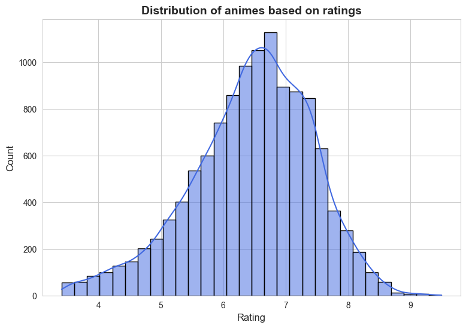

```python
import matplotlib.pyplot as plt
import seaborn as sns
#Now i am going to make an histogram to look at the distribution of data points based on the bmi feature to try to see if I can find some outliers...

# Set a modern style for better visuals
sns.set_style("whitegrid")

# Create a histogram for the 'rating' feature
plt.figure(figsize=(9, 6))
sns.histplot(anime["rating"],
             bins=30,
             kde=True,
             color="royalblue",
             edgecolor="black")

# Add labels and title
plt.xlabel("Rating", fontsize=12)
plt.ylabel("Count", fontsize=12)
plt.title("Distribution of animes based on ratings",
          fontsize=14,
          fontweight="bold")

# Show the plot
plt.show()
```

#### 2. Visualizing the distribution of animes grouped by Type

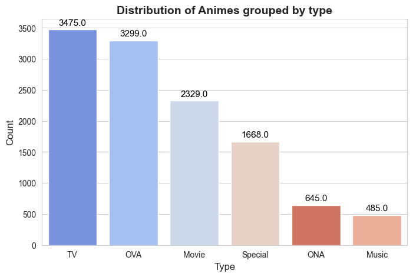

```python
# Making a bar plot to visualize the distribution of the data by Type

plt.figure(figsize=(8, 5))
sns.set_style("whitegrid")  # Improve aesthetics

# Create a count plot
ax = sns.countplot(x="type", data=anime, hue="type", palette="coolwarm", order=anime["type"].value_counts().index, legend = False)

# Add title and labels
plt.title("Distribution of Animes grouped by type", fontsize=14, fontweight="bold")
plt.xlabel("Type", fontsize=12)
plt.ylabel("Count", fontsize=12)

# Display the count values on top of bars
for p in ax.patches:
    ax.annotate(f'{p.get_height()}', (p.get_x() + p.get_width() / 2., p.get_height()),
                ha='center', va='baseline', fontsize=11, color='black', xytext=(0, 5),
                textcoords='offset points')

plt.show()
```

## 2. Studies

### Study 2 - Clustering Algorithms

The goal of this study is to explore and compare two clustering algorithms: KMeans and DBSCAN. These methods will be applied to a selected subset of data from the previous study, using different attribute combinations for analysis.

In this study, we will test multiple variations of each algorithm’s parameters. For KMeans, we will examine at least two different values for k to assess their impact on cluster formation. For DBSCAN, we will experiment with at least two values for eps and min_samples, which influence the density required to form a cluster.

Since clustering relies on a similarity measure, we will limit the analysis to two attributes at a time, making it easier to visually interpret the results. We will illustrate the obtained groupings using visualizations, allowing for an intuitive evaluation of cluster quality.

Finally, we will compare the performance of KMeans and DBSCAN based on visual inspection of the clusters and, optionally, on metrics such as cluster magnitude and cardinality. The objective is to determine which algorithm is more appropriate given the structure of the data and the observed clustering results.

```python
# In this cell, we are going to define the 2 combinations of 2 attributes that will be used in the similarity measure evaluation

X1 = {'x': anime_scaled[['episodes', 'rating']].values, 'subset': ('episodes', 'rating')}

X2 = { 'x': anime_scaled[['rating', 'members']].values, 'subset': ('rating', 'members')}
```

#### a. KMeans clustering analysis

##### 1. Subset 1 (eoisodes X rating)

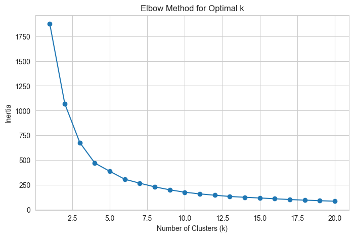

```python
from sklearn.cluster import KMeans
# First, let's determine the optimal number of clusters using theElbow Method

# Try different values for k (number of clusters)
inertia = []
K_range = range(1, 21)

for k in K_range:
    kmeans = KMeans(n_clusters=k, random_state=42, n_init=10)
    kmeans.fit(X1['x'])
    inertia.append(kmeans.inertia_)

# Plot the Elbow curve
plt.figure(figsize=(8, 5))
plt.plot(K_range, inertia, marker='o')
plt.xlabel('Number of Clusters (k)')
plt.ylabel('Inertia')
plt.title('Elbow Method for Optimal k')
plt.show()


# According to the plot, k=5 seems to be the "elbow point" (optimal value for K)
optimal_k = 5
```

```
 The Silhouette score is 0.44792040947225453
```

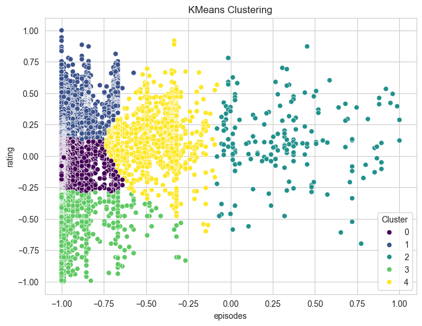

```
'\nThe visual presentation tells us that the KMeans approach with k=5 fails to make distinctive clusters of data points,\nmaybe trying to use different values for K will help \n'
```

```python
from sklearn.metrics import silhouette_score as ss
# Train the KMeans model
def make_kmeans_clusters(df, X, k):
    kmeans = KMeans(n_clusters=k, random_state=42, n_init=10)
    clusters = kmeans.fit_predict(X['x'])

    # Add cluster labels to the original dataset
    df.loc[:,"Cluster_kmean"] = clusters

    # Calculate the silhouette score to evaluate the KMeans clustering approach
    score = ss(X['x'], clusters)
    print(f' The Silhouette score is {score}')

    # Visualize clusters
    plt.figure(figsize=(8, 6))
    X_d = X['x']
    subset = X['subset']
    sns.scatterplot(x=X_d[:, 0], y=X_d[:, 1], hue=clusters, palette="viridis")
    plt.xlabel(subset[0])
    plt.ylabel(subset[1])
    plt.title("KMeans Clustering")
    plt.legend(title="Cluster")
    plt.show()

make_kmeans_clusters(anime, X1, optimal_k)

"""
The visual presentation tells us that the KMeans approach with k=5 fails to make distinctive clusters of data points,
maybe trying to use different values for K will help
"""
```

```
 The Silhouette score is 0.4753717585358633
```

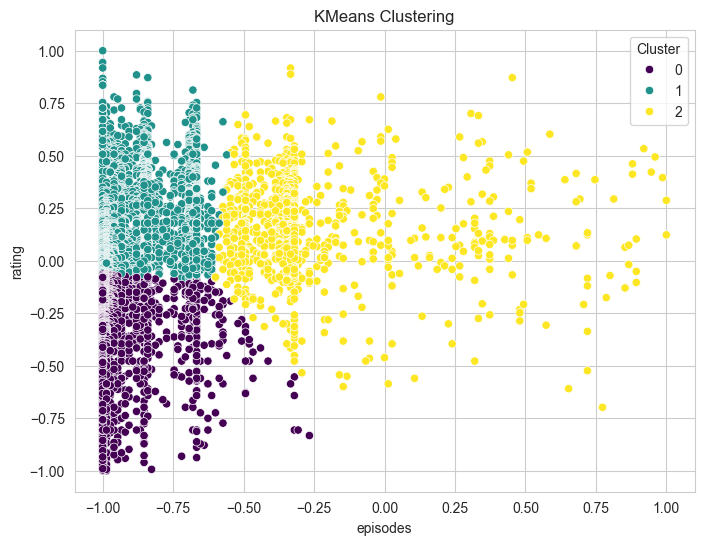

```python
# Trying with K = 3
make_kmeans_clusters(anime, X1, 3)
```

```
 The Silhouette score is 0.4139276259482209
```

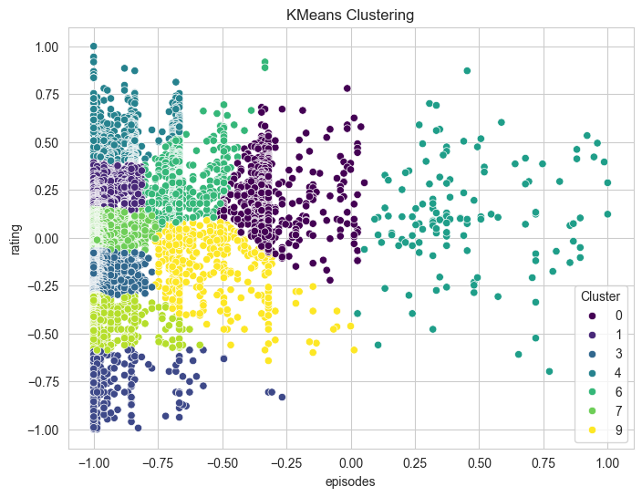

```python
# Trying with K = 10
make_kmeans_clusters(anime, X1, 10)
```

##### 2. Subset 2 ("rating" X "members")

```
 The Silhouette score is 0.4637130233928352
```

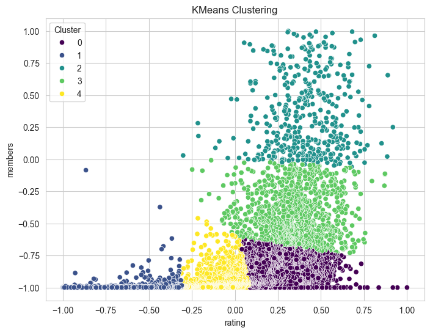

```python
# Now I am going to try with the second subset of features ("rating", "members")
# K = 5
make_kmeans_clusters(anime, X2, 5)
```

```
 The Silhouette score is 0.4294172029530152
```

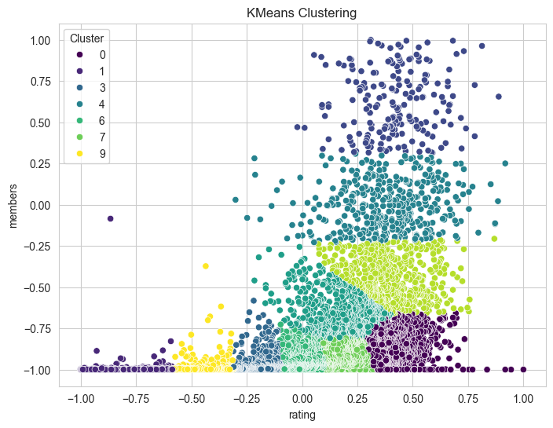

```python
# K = 10
make_kmeans_clusters(anime, X2, 10)
```

```
 The Silhouette score is 0.5007317337794599
```

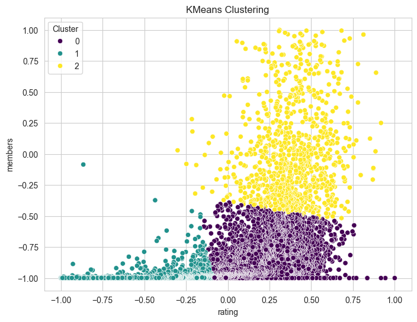

```python
# K = 3
make_kmeans_clusters(anime, X2, 3)
```

- Analysis

These results indicate that a 3-cluster solution provides the best-defined grouping within the dataset. However, the silhouette scores suggest moderate cluster separation, meaning that while some clusters are well-formed, others may overlap or contain points that are not strongly associated with their assigned cluster. The slightly higher scores for X2 indicate that clustering based on Rating and Members yields a more meaningful separation compared to Episodes and Rating.

#### b. DBSCAN clustering Analysis

```python
from sklearn import metrics
from sklearn.cluster import DBSCAN


def make_dbscan_clusters(X_d, eps, min_samples):
    X = X_d['x']
    subset = X_d['subset']
    db = DBSCAN(eps=eps, min_samples=min_samples).fit(X)
    labels = db.labels_

    # Count clusters & noise
    n_clusters_ = len(set(labels)) - (1 if -1 in labels else 0)
    n_noise_ = np.sum(labels == -1)

    # Evaluate the clusters
    score = ss(X, labels)
    print(score)

    # Plot clusters
    plt.figure(figsize=(8, 6))
    unique_labels = set(labels)
    colors = [plt.cm.Spectral(each) for each in np.linspace(0, 1, len(unique_labels))]

    for k, col in zip(unique_labels, colors):
        if k == -1:
            col = [0, 0, 0, 1]  # Black for noise

        class_member_mask = labels == k
        plt.scatter(X[class_member_mask, 0], X[class_member_mask, 1],
                    c=[tuple(col)], edgecolors="k", s=50, label=f"Cluster {k}")

    plt.title(f"DBSCAN Clustering (Clusters: {n_clusters_}, Noise: {n_noise_})")
    plt.xlabel(subset[0])
    plt.ylabel(subset[1])
    plt.legend()
    plt.show()
```

##### 1. Subset 1 (episodes X rating)

```
0.6522269230877424
```

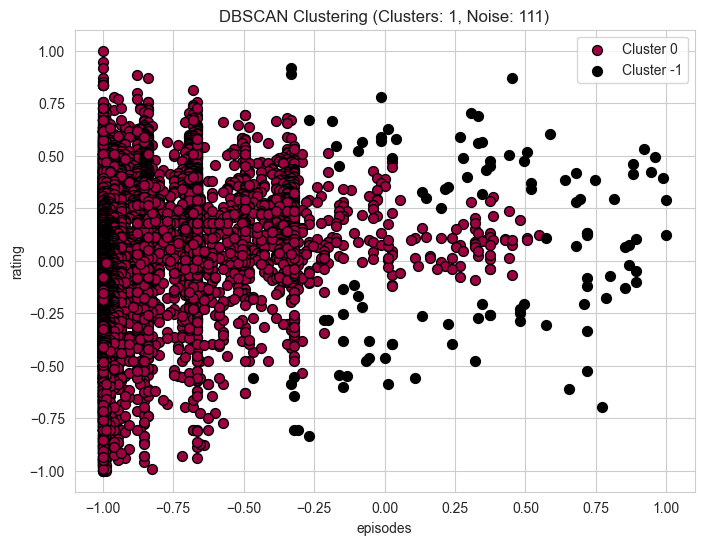

```python
# Run the make_dbscan_clusters on the first subset of features (episodes X rating) with eps = 0.5 and min_samples = 10
make_dbscan_clusters(X1, 0.1, 10)
```

- Analysis

To refine my clustering approach, I will implement a Grid Search strategy in the next step. This will allow me to systematically explore different parameter values and identify the optimal configuration that maximizes the silhouette score. By fine-tuning the clustering parameters, I aim to achieve a better-defined structure before applying my clustering function to X2, the second feature subset used for similarity measurement.

```python
import itertools
# the function get_best_dbcan will perform different dbscan clustering algorithms (with different combinations of parameters) and return the model that had the best silhouette score.
def get_best_dbscan(X):
    best_score = -1.0
    best_labels = [] # We are going to use this variable to get the labels of the best clustering model the first time that it ran.
    best_model = DBSCAN() # we are gonoing to return this variable at the end after trying the different versions and finding the best

    # The combinations of parameters to try
    eps_tab = np.linspace(0.01, 1, num=10)
    min_samples = np.arange(2, 20, step=3)
    combinations = list(itertools.product(eps_tab, min_samples))
    N = len(combinations)

    # The Grid Search execution starts here
    for i, (eps, num_samples) in enumerate(combinations):
        dbs_model = DBSCAN(eps=eps, min_samples=num_samples).fit(X)
        labels = dbs_model.labels_
        labels_set = set(labels)
        num_clusters = len(labels_set)
        if -1 in labels_set: # To remove the noise cluster
            num_clusters -= 1
        # We want to ignore bad clustering results
        if (num_clusters < 2) or (num_clusters > 50):
            c = (eps, num_samples)
            print(f"Combination {c} on iteration {i+1} of {N} has {num_clusters} clusetrs. Moving on")
            continue

        current_score = ss(X, labels)
        if current_score > best_score:
            best_labels = labels
            best_score = current_score
            best_model = dbs_model

    return { 'best_score': best_score,
            'best_labels': best_labels,
            'best_model': best_model}
```

```python
# Now let's apply the function to X1 first
clustering_results = get_best_dbscan(X1['x'])
print(f'The best score reached is {clustering_results['best_score']}')
```

[output not shown]

```python
# Visualizing the clusters after our Grid Search
def visualize_clusters(X_d, labels):
    X = X_d['x']
    subset = X_d['subset']

    # Count clusters & noise
    n_clusters_ = len(set(labels)) - (1 if -1 in labels else 0)
    n_noise_ = np.sum(labels == -1)

    # Plot clusters
    plt.figure(figsize=(8, 6))
    unique_labels = set(labels)
    colors = [plt.cm.Spectral(each) for each in np.linspace(0, 1, len(unique_labels))]

    for k, col in zip(unique_labels, colors):
        if k == -1:
            col = [0, 0, 0, 1]  # Black for noise

        class_member_mask = labels == k
        plt.scatter(X[class_member_mask, 0], X[class_member_mask, 1],
                    c=[tuple(col)], edgecolors="k", s=50, label=f"Cluster {k}")

    plt.title(f"DBSCAN Clustering (Clusters: {n_clusters_}, Noise: {n_noise_})")
    plt.xlabel(subset[0])
    plt.ylabel(subset[1])
    plt.legend()
    plt.show()
```

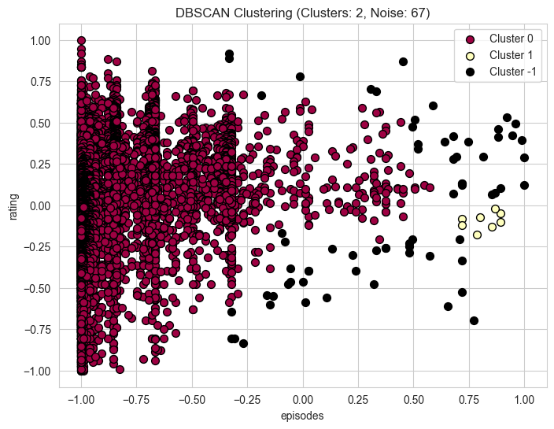

```python
visualize_clusters(X1, clustering_results['best_labels'])
```

##### 2. Subset 2 (ratting X members)

```python
# First step is to apply the function to X2
clustering_results = get_best_dbscan(X2['x'])
print(f'The best score reached is {clustering_results['best_score']}')
```

[output not shown]

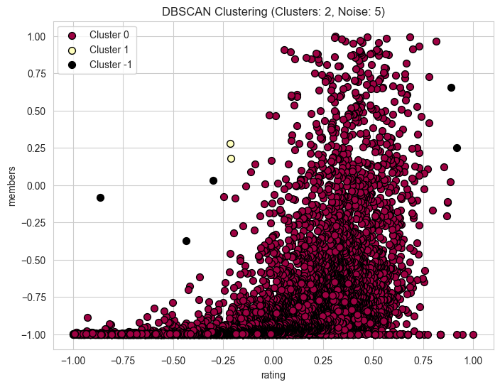

```python
# Visualzing the clusters
visualize_clusters(X2, clustering_results['best_labels'])
```

#### c. Clustering algorithms analysis conclusion

In this study, we explored two clustering algorithms—KMeans and DBSCAN—to segment anime data based on different feature subsets: (Episodes × Rating) and (Rating × Members). Our goal was to evaluate the effectiveness of each algorithm using silhouette scores and visual inspection of the resulting clusters.

### Study 4 - Collaborative Filtering Recomendation System

In this study, we will develop a recommendation system based on collaborative filtering. The foundation of this approach lies in constructing the utility matrix (Rui matrix), where user ratings are used to infer preferences without relying on item metadata.

To generate recommendations, we will perform Matrix Factorization by decomposing the utility matrix into two lower-dimensional matrices, P and Q, which will help approximate missing ratings. We will explore different values for the latent dimension to assess their impact on recommendation quality.

For quantitative evaluation, we will implement a Gold Standard (GS) testing approach by removing 10% of the ratings and comparing predicted ratings against actual values. We will evaluate performance using:

- Mean Squared Error (MSE) to measure the accuracy of predicted scores.
- Precision@K (P@5, P@10) and Mean Reciprocal Rank (MRR) after transforming ratings into a binary relevance system.

The results of these evaluations will provide insights into the effectiveness of our collaborative filtering model and its ability to generate meaningful recommendations.

#### A. Preparation of the data

```python
"""
rating_df = pd.read_csv("rating.csv") # I used this the first time to load in the full dataset

I encounter a lot of problems working with this large amount of data so I am going to use only a sample and
build a recommendation system with the data from the sample

rating_df = rating_df.sample(n=500000, random_state = 77)
rating_df.to_csv("rating_sample.csv")"""

rating_df = pd.read_csv("https://raw.githubusercontent.com/hkala042/Hil_datasets/refs/heads/main/rating_sample.csv")
rating_df.info()
```

[output not shown]

```python
# Create mapping for users and items
users = rating_df['user_id'].unique()  # List of users
items = rating_df['anime_id'].unique()  # List of items

print(f'There are {len(users)} different users in the dataset')
print(f'There are {len(items)} different animes in the dataset')

# A rating -1 indicates a missing value of the rating for one particular user
```

[output not shown]

```python
missing_ratings = (rating_df.rating == -1).sum()
missing_ratings
# We have 94649 missing ratings
```

[output not shown]

```python
# In this cell, the utility matrix is going to be built using the data from the rating_df
from collections import defaultdict

# Create mappings for users and items
users_index = {user: idx for idx, user in enumerate(users)}
items_index = {item: idx for idx, item in enumerate(items)}

# Initialize the utility matrix with correct dimensions
R = np.zeros((len(users), len(items)), dtype=int)

# Fill the matrix with ratings
for row in rating_df.itertuples(index=False):
    user_ind = users_index[row.user_id]
    item_ind = items_index[row.anime_id]

    if row.rating != -1:  # Only store valid ratings
        R[user_ind, item_ind] = row.rating

# Check first 5 ratings of user at index 10
R[10, :5]
```

[output not shown]

#### B. Implementing the recommendation system based on collaborative filtering

```python
## The Matrix factorization function that is going to use to produce collaborative filtering based predictions
# This function is inspired from the function implememted by Denise Chen (the function can be found in the article "Recommender System — Matrix Factorization" - See Reference at the end of the notebook)
def matrix_factorization(R, P, Q, K, steps=30, alpha=0.1, beta=0.2):
    '''
    R: rating matrix
    P: |U| * K (User features matrix)
    Q: |D| * K (Item features matrix)é
    K: latent features
    steps: iterations
    alpha: learning rate
    beta: regularization parameter'''
    Q = Q.T

    for step in range(steps):
        for i in range(len(R)):
            for j in range(len(R[i])):
                if R[i][j] > 0:
                    # calculate error
                    eij = R[i][j] - np.dot(P[i,:],Q[:,j])

                    for k in range(K):
                        # calculate gradient with a and beta parameter
                        P[i][k] = P[i][k] + alpha * (2 * eij * Q[k][j] - beta * P[i][k])
                        Q[k][j] = Q[k][j] + alpha * (2 * eij * P[i][k] - beta * Q[k][j])

        eR = np.dot(P,Q)

        e = 0

        for i in range(len(R)):

            for j in range(len(R[i])):

                if R[i][j] > 0:

                    e = e + pow(R[i][j] - np.dot(P[i,:],Q[:,j]), 2)

                    for k in range(K):

                        e = e + (beta/2) * (pow(P[i][k],2) + pow(Q[k][j],2))
        # 0.001: local minimum
        if e < 0.001:

            break

    return P, Q.T
```

```python
# Build the recommendation system using the matrix_factorization function to approximate a completed utility matrix
# Define the number of latent features (K)
K = 10 # This value can be changed to evaluate the performance under different circumstances

# Initialize P (Users x K) and Q (Items x K) randomly
num_users = len(users)
num_items = len(items)

P = np.random.rand(num_users, K)
Q = np.random.rand(num_items, K)

# Apply matrix factorization
P_optimized, Q_optimized = matrix_factorization(R, P, Q, K)

# Compute the approximate utility matrix
R_predicted = np.dot(P_optimized, Q_optimized.T)

# Make a prediction example
user_idx = 10
item_idx = 5
predicted_rating = R_predicted[user_idx, item_idx]

print(f"Predicted rating for User {user_idx} and Item {item_idx}: {predicted_rating:.2f}")
```

[output not shown]

#### C. Qualitative and quantitative evaluations

```python
# Randomly remove 10% of the ratings from the utility matrix. These removed ratings will be our Gold Standard (GS).
# We'll keep track of which ratings were removed for later comparison.

# Sample 10% of ratings from the original dataset to create GS
# Shuffle the dataset and select 10% of ratings randomly
num_ratings = len(rating_df)
remove_percentage = 0.1
num_remove = int(num_ratings * remove_percentage)

# Randomly select 10% of the data to be removed
removed_ratings = rating_df.sample(n=num_remove, random_state=42)

# Create Gold Standard by keeping the ratings that were removed
gs = removed_ratings.copy()

# Remove those 10% of ratings from the original dataset
train_data = sample_df.drop(removed_ratings.index)

print(f"Number of ratings in GS: {len(gs)}")
print(f"Number of ratings in training data: {len(train_data)}")
```

[output not shown]

```python
# Predict the ratings for the user-item pairs in GS
predictions = []

for _, row in gs.iterrows():
    user_idx = users_index[row['user_id']]
    item_idx = items_index[row['anime_id']]

    # Store the predicted rating and the actual rating
    predictions.append((R_predicted, row['rating']))

# Convert the predictions list to a DataFrame for easier analysis
predictions_df = pd.DataFrame(predictions, columns=['predicted', 'actual'])
```

```python
# We're going to use the Mean Square Error to compare the predicted ratings with the actual ratings in the Gold Standard (GS)
from sklearn.metrics import mean_squared_error

# Calculate the Mean Squared Error (MSE) between predicted and actual ratings
mse = mean_squared_error(predictions_df['actual'], predictions_df['predicted'])
print(f"Mean Squared Error (MSE): {mse}")
```

[output not shown]

- Evaluation 2 - Precision at K and Mean Reciprocal Rank (MRR) For Evaluation 2, we need to treat ratings as relevant or non-relevant based on a threshold (e.g., ratings of 4 or 5 are relevant, ratings of 0 to 3 are irrelevant). After that, we can calculate P@K and MRR.

```python
# Convert actual ratings to binary relevance (1 = relevant, 0 = irrelevant)
gs['binary_relevance'] = gs['rating'].apply(lambda x: 1 if x >= 4 else 0)

predictions_df['predicted_binary'] = predictions_df['predicted'].apply(lambda x: 1 if x >= 4 else 0)
```

- We calculate Precision at K (P@K) for the top K recommended items for each user. Precision is the proportion of relevant items in the top K recommendations.

```python
def precision_at_k(predictions_df, k=5):
    # Sort predictions by predicted score for each user
    predictions_df_sorted = predictions_df.sort_values(by='predicted', ascending=False)

    # Select the top K predictions
    top_k = predictions_df_sorted.head(k)

    # Calculate Precision at K
    relevant_count = sum(top_k['predicted_binary'])
    return relevant_count / k

# Calculate Precision at 5 and 10
P_at_5 = precision_at_k(predictions_df, k=5)
P_at_10 = precision_at_k(predictions_df, k=10)

print(f"Precision at 5 (P@5): {P_at_5}")
print(f"Precision at 10 (P@10): {P_at_10}")
```

[output not shown]

- The Mean Reciprocal Rank (MRR) measures the rank position of the first relevant item in the list of recommendations.

```python
def mean_reciprocal_rank(predictions_df):
    # Find the rank of the first relevant item (binary relevance = 1)
    predictions_df_sorted = predictions_df.sort_values(by='predicted', ascending=False)
    relevant_ranks = predictions_df_sorted[predictions_df_sorted['predicted_binary'] == 1].index

    if len(relevant_ranks) > 0:
        return 1 / (relevant_ranks[0] + 1)  # Rank starts at 0, so we add 1 to avoid division by zero
    return 0

# Calculate MRR
MRR = mean_reciprocal_rank(predictions_df)
print(f"Mean Reciprocal Rank (MRR): {MRR}")
```

[output not shown]

## 3. Conclusion

This study focused on building a collaborative filtering recommendation system using matrix factorization on a large user-item rating dataset. The process involved constructing a sparse user-item matrix, applying matrix factorization to approximate missing ratings, and evaluating the model using metrics like Mean Squared Error (MSE), Precision at K (P@K), and Mean Reciprocal Rank (MRR).

While the study demonstrated the value of matrix factorization and evaluation metrics, it also highlighted the need for more efficient algorithms and scalability solutions, such as distributed computing or advanced optimization techniques, to handle large-scale datasets in real-world recommender systems.

## 4. References

- https://scikit-learn.org/stable/auto_examples/cluster/plot_dbscan.html
- https://www.youtube.com/watch?v=VO_uzCU_nKw&list=WL&index=2
- https://medium.com/data-science/recommendation-system-matrix-factorization-d61978660b4b